# Unlocking Customer Insights: A Statistical Investigation

#### Statistics Mini Project

- Name: Tanmay Mandal
- Course: Statistics for Data Analytics
- Date: 20/03/2026

## I. Introduction:

This project analyzes customer behavior using statistical techniques including descriptive statistics, visualization, and hypothesis testing.

## II. Project Objective:

The objective of this project is to analyze customer data to identify patterns in spending, engagement, and demographics, and to support data-driven business decisions.

```python
import os
os.getcwd()
```

```
'C:\\Users\\VORTEX\\OneDrive\\Desktop\\Data Analysis\\Statistics\\Mini Project'
```

## III. Data Understanding:

```python
# Importing Important libraries
import pandas as pd
import numpy as np
import matplotlib.pyplot as plt
import seaborn as sns
from scipy import stats
```

```python
# Loading dataset
df = pd.read_csv("US_Customer_Insights_Dataset.csv")

print("Loaded Successfully")
```

```
Loaded Successfully
```

### i) Dataset Overview-

```python
df.head()
```

|  | CustomerID | Name | State | Education | Gender | Age | Married | NumPets | JoinDate | TransactionDate | MonthlySpend | DaysSinceLastInteraction |
| --- | --- | --- | --- | --- | --- | --- | --- | --- | --- | --- | --- | --- |
| 0 | CUST10319 | Scott Perez | Florida | High School | Non-Binary | 47 | Yes | 1 | 9/19/21 | 9/2/24 | 1281.74 | 332 |
| 1 | CUST10695 | Jennifer Burton | Washington | Master | Male | 72 | Yes | 0 | 4/5/24 | 6/2/24 | 429.46 | 424 |
| 2 | CUST10297 | Michelle Rogers | Arizona | Master | Female | 40 | Yes | 2 | 7/24/24 | 2/28/25 | 510.34 | 153 |
| 3 | CUST10103 | Brooke Hendricks | Texas | Master | Male | 27 | Yes | 0 | 8/12/23 | 3/29/25 | 396.47 | 124 |
| 4 | CUST10219 | Karen Johns | Texas | High School | Female | 28 | Yes | 1 | 12/6/21 | 7/24/22 | 139.68 | 1103 |

### ii) Data Types and Structure-

```python
df.info()
```

```
<class 'pandas.core.frame.DataFrame'>
RangeIndex: 10675 entries, 0 to 10674
Data columns (total 12 columns):
 #   Column                    Non-Null Count  Dtype
---  ------                    --------------  -----
 0   CustomerID                10675 non-null  object
 1   Name                      10675 non-null  object
 2   State                     10675 non-null  object
 3   Education                 10675 non-null  object
 4   Gender                    10675 non-null  object
 5   Age                       10675 non-null  int64
 6   Married                   10675 non-null  object
 7   NumPets                   10675 non-null  int64
 8   JoinDate                  10675 non-null  object
 9   TransactionDate           10675 non-null  object
 10  MonthlySpend              10675 non-null  float64
 11  DaysSinceLastInteraction  10675 non-null  int64
dtypes: float64(1), int64(3), object(8)
memory usage: 1000.9+ KB
```

```python
df.nunique()
```

```
CustomerID                  1000
Name                         990
State                         10
Education                      5
Gender                         3
Age                           63
Married                        2
NumPets                        5
JoinDate                     731
TransactionDate             1605
MonthlySpend                9843
DaysSinceLastInteraction    1605
dtype: int64
```

### iii) Checking Missing Values -

```python
df.isnull().sum()
```

```
CustomerID                  0
Name                        0
State                       0
Education                   0
Gender                      0
Age                         0
Married                     0
NumPets                     0
JoinDate                    0
TransactionDate             0
MonthlySpend                0
DaysSinceLastInteraction    0
dtype: int64
```

### iv) Date Engineering-

```python
df['JoinDate'] = pd.to_datetime(df['JoinDate'], format='%m/%d/%y')
df['TransactionDate'] = pd.to_datetime(df['TransactionDate'], format='%m/%d/%y')

print("\nDATA TYPES:\n", df.dtypes)
```

```
DATA TYPES:
 CustomerID                          object
Name                                object
State                               object
Education                           object
Gender                              object
Age                                  int64
Married                             object
NumPets                              int64
JoinDate                    datetime64[ns]
TransactionDate             datetime64[ns]
MonthlySpend                       float64
DaysSinceLastInteraction             int64
dtype: object
```

## IV. Descriptive Statistics:

Descriptive statistics were used to summarize the dataset.

- The mean represents the average value of numerical variables such as age, monthly spending, and customer activity.
- The median indicates the middle value and helps reduce the impact of extreme values.
- The standard deviation measures the variability or spread of the data.
- The mode represents the most frequently occurring value in categorical variables such as gender, education, marital status, and state.

```python
print("===== DATA SUMMARY =====")

print("\n🔢 Numerical Variables:\n")
print(df.select_dtypes(include=['number']).describe())

print("\n📊 Categorical Variables:\n")
print(df.select_dtypes(include=['object']).describe())

print("\n⭐ Modes:\n")
for col in df.select_dtypes(include=['object']).columns:
    print(f"{col}: {df[col].mode()[0]}")
```

```
===== DATA SUMMARY =====

🔢 Numerical Variables:

                Age       NumPets  MonthlySpend  DaysSinceLastInteraction
count  10675.000000  10675.000000  10675.000000              10675.000000
mean      49.474567      1.340515    331.610315                538.469883
std       18.221365      1.150849    225.799253                398.766747
min       18.000000      0.000000      3.890000                  1.000000
25%       35.000000      0.000000    165.495000                218.000000
50%       49.000000      1.000000    282.110000                445.000000
75%       66.000000      2.000000    443.255000                788.500000
max       80.000000      4.000000   1740.420000               1791.000000

📊 Categorical Variables:

       CustomerID            Name       State Education Gender Married
count       10675           10675       10675     10675  10675   10675
unique       1000             990          10         5      3       2
top     CUST10798  Joseph Mcbride  California    Master   Male      No
freq           24              29        1180      2269   3791    5583

⭐ Modes:

CustomerID: CUST10798
Name: Joseph Mcbride
State: California
Education: Master
Gender: Male
Married: No
```

## V. Data Visualization:

### a) Histogram (Age, Monthly Spend)

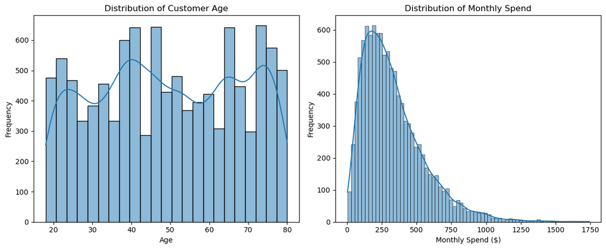

```python
plt.figure(figsize=(12,5))

plt.subplot(1,2,1)
sns.histplot(df['Age'], kde=True)
plt.title("Distribution of Customer Age")
plt.xlabel("Age")
plt.ylabel("Frequency")

plt.subplot(1,2,2)
sns.histplot(df['MonthlySpend'], kde=True)
plt.title("Distribution of Monthly Spend")
plt.xlabel("Monthly Spend ($)")
plt.ylabel("Frequency")

plt.tight_layout()
plt.show()
```

#### Insights-

[output not shown]

### b) Boxplots (Age, Monthly Spend)

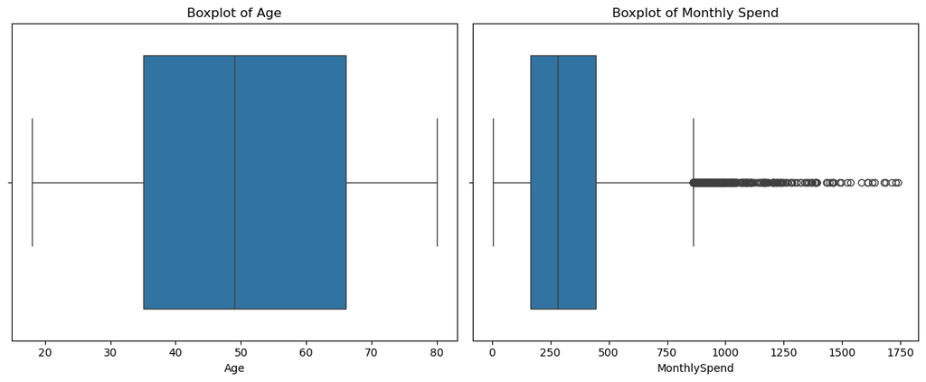

```python
plt.figure(figsize=(12,5))

plt.subplot(1,2,1)
sns.boxplot(x=df['Age'])
plt.title("Boxplot of Age")

plt.subplot(1,2,2)
sns.boxplot(x=df['MonthlySpend'])
plt.title("Boxplot of Monthly Spend")

plt.tight_layout()
plt.show()
```

#### Insights-

```
•	MonthlySpend shows outliers, confirming high-spending customers.
```

### c) Bar Charts (Gender, Education, State)

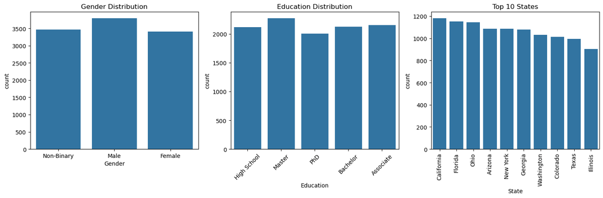

```python
plt.figure(figsize=(15,5))

plt.subplot(1,3,1)
sns.countplot(x='Gender', data=df)
plt.title("Gender Distribution")

plt.subplot(1,3,2)
sns.countplot(x='Education', data=df)
plt.xticks(rotation=45)
plt.title("Education Distribution")

plt.subplot(1,3,3)
sns.countplot(x='State', data=df, order=df['State'].value_counts().index[:10])
plt.xticks(rotation=90)
plt.title("Top 10 States")

plt.tight_layout()
plt.show()
```

#### Insights-

```
•	Gender and education are fairly evenly distributed.
•	Some states have slightly higher customer concentration.
```

### d) Scatter Plot (Age vs Monthly Spend)

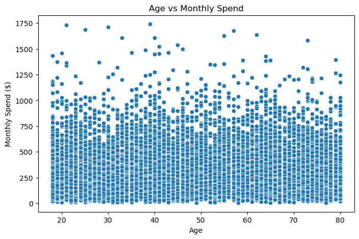

```python
plt.figure(figsize=(8,5))
sns.scatterplot(x='Age', y='MonthlySpend', data=df)
plt.title("Age vs Monthly Spend")
plt.xlabel("Age")
plt.ylabel("Monthly Spend ($)")
plt.show()
```

#### Insights-

```
•	No clear trend → Age does not strongly influence spending
```

### e) KDE Plot (Spending Distribution)

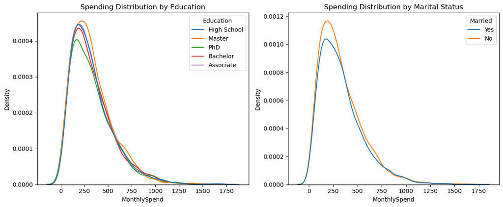

```python
plt.figure(figsize=(12,5))

plt.subplot(1,2,1)
sns.kdeplot(data=df, x='MonthlySpend', hue='Education')
plt.title("Spending Distribution by Education")

plt.subplot(1,2,2)
sns.kdeplot(data=df, x='MonthlySpend', hue='Married')
plt.title("Spending Distribution by Marital Status")

plt.tight_layout()
plt.show()
```

#### Insights-

```
•	Spending patterns are similar across education & marital groups
```

## VI. Bivariate Analysis:

### 1. Correlation Matrix

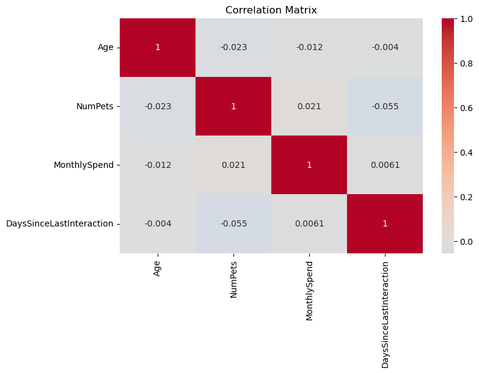

```python
plt.figure(figsize=(8,5))
corr = df[['Age','NumPets','MonthlySpend','DaysSinceLastInteraction']].corr()
sns.heatmap(corr, annot=True, cmap='coolwarm', center=0)
plt.title("Correlation Matrix")
plt.show()
```

#### Insights-

- Corelations are weak - no strong linear realtionships.

```python
corr, p = stats.pearsonr(df['Age'], df['DaysSinceLastInteraction'])

print("Correlation:", corr)
print("P-value:", p)
```

```
Correlation: -0.003970230104955046
P-value: 0.6816905437300954
```

### 2. Crosstab (Gender vs Married)

```python
pd.crosstab(df['Gender'], df['Married'])
```

| Married Gender | No | Yes |
| --- | --- | --- |
| Female | 1797 | 1616 |
| Male | 1892 | 1899 |
| Non-Binary | 1894 | 1577 |

### 3. Grouped Statistics (MonthlySpend by State, Education, Gender)

```python
df.groupby('State')['MonthlySpend'].mean()
```

```
State
Arizona       341.489135
California    339.183492
Colorado      323.083462
Florida       327.696892
Georgia       328.354648
Illinois      332.589591
New York      332.151244
Ohio          340.187860
Texas         319.506770
Washington    329.444078
Name: MonthlySpend, dtype: float64
```

```python
df.groupby('Education')['MonthlySpend'].mean()
```

```
Education
Associate      327.884408
Bachelor       331.884753
High School    332.215712
Master         334.252305
PhD            331.690090
Name: MonthlySpend, dtype: float64
```

```python
df.groupby('Gender')['MonthlySpend'].mean()
```

```
Gender
Female        331.361310
Male          333.174068
Non-Binary    330.147240
Name: MonthlySpend, dtype: float64
```

## VII. Hypothesis Testing:

- H0: No significant relationships exist between variables
- H1: Significant relationships exist between variables

### 1. Age vs MonthlySpend (Correlation Test)

```
•	H0: No correlation between Age and MonthlySpend
•	H1: Correlation exists
```

```python
corr, p = stats.pearsonr(df['Age'], df['MonthlySpend'])

print(f"Correlation: {corr:.4f}")
print(f"P-value: {p:.4f}")
```

```
Correlation: -0.0123
P-value: 0.2030
```

##### * Correlation Test Results:

- correlation: -0.012
- p-value: 0.203
- Decision: p-value > 0.05 → fail to reject H0
- Conclusion: No significant relationship

### 2. Age vs Customer DaysSinceLastInteraction (Correlation Test)

```
•	H0: There is no correlation between Age and DaysSinceLastInteraction
•	H1: There is a correlation between Age and DaysSinceLastInteraction
```

```python
corr, p = stats.pearsonr(df['Age'], df['DaysSinceLastInteraction'])

print(f"Correlation: {corr:.4f}")
print(f"P-value: {p:.4f}")
```

```
Correlation: -0.0040
P-value: 0.6817
```

##### * Correlation Test Result:

```
•	Correlation: -0.004
•	p-value: 0.682
```

Decision: • Since p-value > 0.05, we fail to reject the null hypothesis

Conclusion: • There is no significant relationship between age and customer activity. Older customers are not necessarily less active.

### 3. Gender vs Customer Activity (T-test)

[output not shown]

```python
male = df[df['Gender'] == 'Male']['DaysSinceLastInteraction']
female = df[df['Gender'] == 'Female']['DaysSinceLastInteraction']

stats.ttest_ind(male, female)
```

```
TtestResult(statistic=np.float64(1.6704389444143242), pvalue=np.float64(0.094876002312686), df=np.float64(7202.0))
```

##### * T-test Results:

- t-statistic: 1.67
- p-value: 0.0949
- Decision: p-value > 0.05 → fail to reject H0
- Conclusion: No significant difference between groups

### 4. Education vs MonthlySpend (ANOVA)

```
•	H0: Mean MonthlySpend is same across all education levels
•	H1: At least one group is different
```

```python
groups = [group['MonthlySpend'].values for name, group in df.groupby('Education')]

stats.f_oneway(*groups)
```

```
F_onewayResult(statistic=np.float64(0.2288066867370917), pvalue=np.float64(0.922359467759936))
```

##### * ANOVA Test Result:

- F-statistic: 0.23
- p-value: 0.9223
- Decision: p-value > 0.05 → fail to reject H0
- Conclusion: Education level does NOT significantly affect MonthlySpend

### 5. Categorical Relationship b/w Marital status vs Number of pets (Chi-square)

```
•	H0: No relationship between marital status and number of pets
•	H1: There is a relationship
```

```python
table = pd.crosstab(df['Married'], df['NumPets'])

stats.chi2_contingency(table)
```

```
Chi2ContingencyResult(statistic=np.float64(177.63953668537033), pvalue=np.float64(2.3957232932397494e-37), dof=4, expected_freq=array([[1592.00487119, 1676.20749415, 1436.15156909,  578.95840749,
         299.67765808],
       [1451.99512881, 1528.79250585, 1309.84843091,  528.04159251,
         273.32234192]]))
```

##### * Chi-Square Test Result:

- Chi-square statistic: 177.64
- p-value: 2.39e-37
- Degrees of freedom: 4
- Decision: p-value < 0.05 → reject H0
- Conclusion: There is a significant relationship between marital status and number of pets

## VIII. Business Insights:

[output not shown]

### Additional Insights -

```
• Customers with higher monthly spending form a small but important segment contributing significantly to revenue.

• Since most variables show weak correlations, customer behavior is likely influenced by multiple factors rather than a single demographic variable.

• Customers with longer inactivity periods (high DaysSinceLastInteraction) represent potential churn risk and should be targeted with re-engagement campaigns.

• The presence of variability in spending suggests the opportunity to classify customers into low, medium, and high-value segments.
```

## IX. Recommendations:

- Personalize marketing based on spending and engagement behavior
- Target high-spending customers with premium offers
- Re-engage inactive customers through segmentation strategies
- Use pet ownership and behavioural patterns for targeted campaigns
- Monitor customer engagement regularly to reduce churn

### # Executive summary:

This analysis used descriptive statistics, visualizations, and hypothesis testing to uncover patterns in customer behavior. Key insights include diverse spending behavior, minimal differences in engagement by gender or geography, and opportunities for pet-based and behavior-driven targeting. Recommendations include segmentation-based marketing campaigns to optimize revenue and re-engagement.

## X. Conclusion:

Customer behavior shows high variability in spending. However, no strong statistical relationships were found between age, gender, or geography and key metrics.